# Figure 3

John Favate

2022-07-14 10:58:08

```r
# Prevent printing of warnings and such in the HTML
knitr::opts_chunk$set(warning = FALSE, message = FALSE, fig.align = "center")
```

Load packages

```r
library(tidyverse)
library(scales)
library(nlme)
library(ggpointdensity)
library(ggpubr)
library(gridExtra)
library(patchwork)
```

Read in data

```r
all.data <- read_csv("../../data_frames/all_data.csv") %>%
  filter(gene_type == "ECB")

kdf <- read_csv("../../data_frames/table_s1_read_counts.csv")

my.mutations <- read_csv("../../data_frames/table_s12_mutations.csv")

genome.wide.codon.density <- read_csv("../../data_frames/table_s8_genome_wide_codon_densities.csv")

kdf <- read_csv("../../data_frames/table_s1_read_counts.csv")
```

This is a set of colors for the amino acids, and also the order in which I want them graphed.

```r
my.colors <- c("black","#a0504e","#5bb748","#9856c9","#adb839","#5e6ccc","#d59b34","#de6fd2","#5fbc85","#c14092","#3f7c44","#d13c61","#3fbfbc","#cd5632","#5e95cf","#90a452","#c290d5","#7b6c27","#90578d","#cd8e5a","#e48197")

aa.order <- genome.wide.codon.density$amino_acid %>%
  unique() %>%
  sort()
```

```r
mut.levels <- all.data %>%
  select(line, mutator) %>%
  arrange(mutator, line) %>%
  unique() %>%
  pull(line)

mut.colors <- c(rep("black", 6), rep("firebrick3", 5))
```

### Panel A

RNAseq and riboseq fold changes are correlated

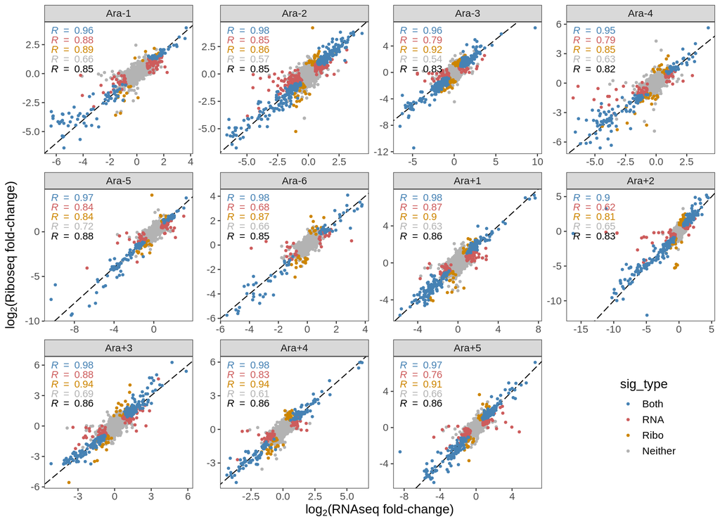

```r
all.data %>%
  mutate(
    sig_type = case_when(
      ds_padj_rna <= .01 & ds_padj_ribo <= .01 ~ "Both",
      !is.na(ds_padj_rna) & ds_padj_rna <= .01 ~ "RNA",
      !is.na(ds_padj_ribo) & ds_padj_ribo <= .01 ~ "Ribo"
    ),
    sig_type = ifelse(is.na(sig_type), "Neither", sig_type),
    sig_type = factor(sig_type, c("Both", "RNA", "Ribo", "Neither"))) %>%
  arrange(desc(sig_type)) %>%
  ggplot(., aes(ds_log2foldchange_rna, ds_log2foldchange_ribo, color = sig_type))+
  geom_abline(aes(slope = 1, intercept = 0), linetype = 5)+
  geom_point(size = 1)+
  facet_wrap(~line, ncol = 4, scales = "free")+
  theme_bw()+
  theme(text = element_text(size = 14),
        panel.grid = element_blank(),
        legend.position = c(.9, .15))+
  stat_cor(aes(label = ..r.label..), label.y.npc = .99, show.legend = FALSE)+
  stat_cor(inherit.aes = FALSE, aes(ds_log2foldchange_rna, ds_log2foldchange_ribo, label = ..r.label..), label.y.npc = .67)+
  scale_color_manual(values = c("steelblue", "indianred", "orange3", "grey70"))+
  labs(x = expression(paste(log[2], "(RNAseq fold-change)")),
       y = expression(paste(log[2], "(Riboseq fold-change)")))
```

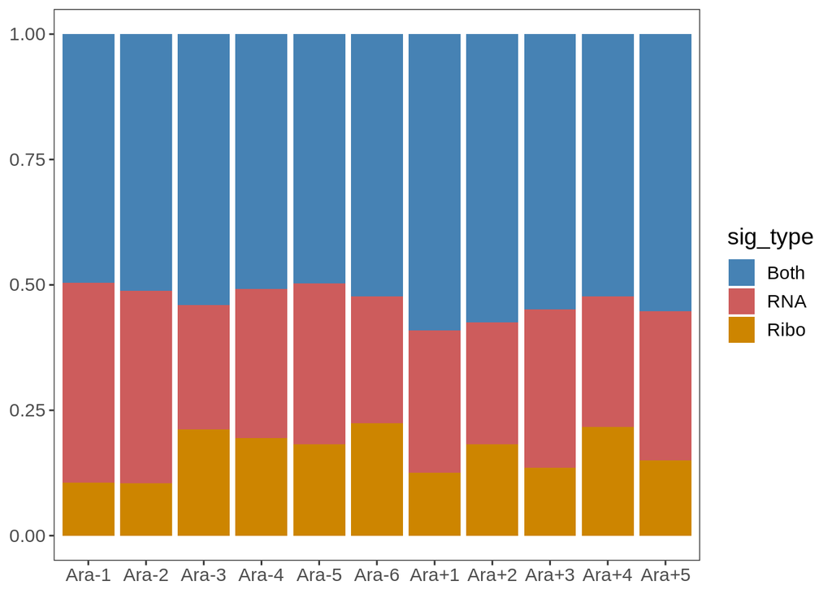

```r
all.data %>%
  mutate(
    sig_type = case_when(
      ds_padj_rna <= .01 & ds_padj_ribo <= .01 ~ "Both",
      !is.na(ds_padj_rna) & ds_padj_rna <= .01 ~ "RNA",
      !is.na(ds_padj_ribo) & ds_padj_ribo <= .01 ~ "Ribo"
    ),
    sig_type = ifelse(is.na(sig_type), "Neither", sig_type),
    sig_type = factor(sig_type, c("Both", "RNA", "Ribo", "Neither"))) %>%
  filter(sig_type != "Neither") %>%
  ggplot(., aes(line, fill = sig_type))+
  geom_bar(position = "fill")+
  scale_fill_manual(values = c("steelblue", "indianred", "orange3"))+
  theme_bw()+
  theme(text = element_text(size = 14),
        panel.grid = element_blank())+
  labs(x = NULL, y = NULL)
```

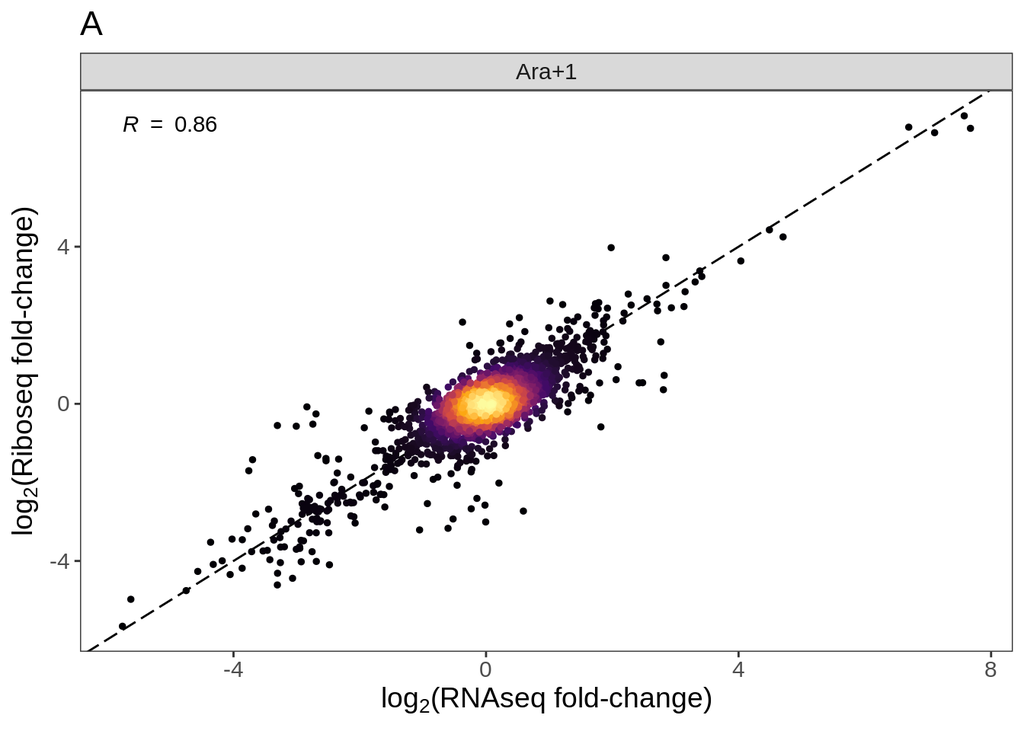

```r
pa <- all.data %>%
  filter(line == "Ara+1") %>%
  ggplot(., aes(ds_log2foldchange_rna, ds_log2foldchange_ribo))+
  geom_abline(aes(slope = 1, intercept = 0), linetype = 5)+
  geom_pointdensity(size = 1)+
  theme_bw()+
  theme(text = element_text(size = 14),
        panel.grid = element_blank())+
  stat_cor(aes(label = ..r.label..), label.y.npc = .99, show.legend = FALSE)+
  labs(x = expression(paste(log[2], "(RNAseq fold-change)")),
       y = expression(paste(log[2], "(Riboseq fold-change)")),
       title = "A")+
  scale_color_viridis_c(option = "B", guide = "none")+
  facet_wrap(~line)

pa
```

### Panel B

Riborex results

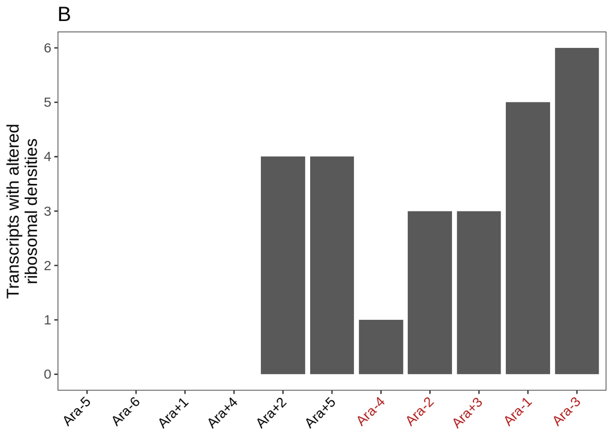

```r
# find the number of significant riborex genes in each line
bdf <- all.data %>%
  group_by(line, mutator) %>%
  tally(rr_sig == TRUE) %>%
  ungroup() %>%
  arrange(mutator, n)

mut.lines <- bdf %>%
  filter(mutator == TRUE) %>%
  pull(line) %>%
  as.character()

# line order
bdf$line <- factor(bdf$line, bdf$line)

# x axis colors
b.colors <- sapply(bdf$line, function(x){
  if (x %in% mut.lines){
    return("firebrick")
  } else {
    return("black")
  }
})

# the plot
pb <- bdf %>%
  ggplot(., aes(line, n))+
  geom_col()+
  theme_bw()+
  theme(panel.grid = element_blank(),
        text = element_text(size = 14),
        axis.text.x = element_text(angle = 45, vjust = 1.1, hjust = 1.1, color = b.colors))+
  scale_y_continuous(breaks = 0:6)+
  labs(x = NULL,
       y = "Transcripts with altered\nribosomal densities",
       title = "B")

pb
```

### Panel C

Codon heatmap. Load and shape the codon data.

```r
# get the evovled lines density
evos <- genome.wide.codon.density %>%
  group_by(codon, line, amino_acid) %>%
  summarise(mean_dens_sans_zero = mean(avg_ribo_n),
            var_dens_sans_zero = var(avg_ribo_n),
            std_dens_sans_zero = sd(avg_ribo_n),
            mean_dens_with_zero = mean(avg_ribo_n_w_0),
            var_dens_with_zero = var(avg_ribo_n_w_0),
            std_dens_with_zero = sd(avg_ribo_n_w_0)) %>%
  ungroup() %>%
  filter(!(grepl("REL", line)))

# get the ancestral densities
ancs <- genome.wide.codon.density %>%
  filter(grepl("REL", line)) %>%
  select(-line, -replicate) %>%
  group_by(codon, amino_acid) %>%
  summarise(mean_dens_sans_zero = mean(avg_ribo_n),
            var_dens_sans_zero = var(avg_ribo_n),
            std_dens_sans_zero = sd(avg_ribo_n),
            mean_dens_with_zero = mean(avg_ribo_n_w_0),
            var_dens_with_zero = var(avg_ribo_n_w_0),
            std_dens_with_zero = sd(avg_ribo_n_w_0)) %>%
  ungroup()

# join them
joined.dens.df <- left_join(evos, ancs, by = c("codon", "amino_acid"), suffix = c("_evo", "_anc"))

head(joined.dens.df)
```

| codon | line | amino_acid | mean_dens_sans_zero_evo | var_dens_sans_zero_evo | std_dens_sans_zero_evo | mean_dens_with_zero_evo | var_dens_with_zero_evo | std_dens_with_zero_evo | mean_dens_sans_zero_anc | var_dens_sans_zero_anc | std_dens_sans_zero_anc | mean_dens_with_zero_anc | var_dens_with_zero_anc | std_dens_with_zero_anc |
| --- | --- | --- | --- | --- | --- | --- | --- | --- | --- | --- | --- | --- | --- | --- |
| AAA | Ara-1 | K | 1.002242 | 2.726922e-03 | 0.052219935 | 1.010839 | 0.0106259675 | 0.10308233 | 0.9983592 | 0.0003065321 | 0.01750806 | 0.9835398 | 0.0005666558 | 0.02380453 |
| AAA | Ara-2 | K | 1.066163 | 4.256334e-04 | 0.020630883 | 1.120620 | 0.0023418116 | 0.04839227 | 0.9983592 | 0.0003065321 | 0.01750806 | 0.9835398 | 0.0005666558 | 0.02380453 |
| AAA | Ara-3 | K | 1.032313 | 8.866947e-05 | 0.009416447 | 1.060526 | 0.0008252184 | 0.02872661 | 0.9983592 | 0.0003065321 | 0.01750806 | 0.9835398 | 0.0005666558 | 0.02380453 |
| AAA | Ara-4 | K | 1.105705 | 1.003644e-02 | 0.100182048 | 1.188528 | 0.0456826106 | 0.21373491 | 0.9983592 | 0.0003065321 | 0.01750806 | 0.9835398 | 0.0005666558 | 0.02380453 |
| AAA | Ara-5 | K | 1.010755 | 4.239301e-03 | 0.065109911 | 1.026993 | 0.0131459078 | 0.11465561 | 0.9983592 | 0.0003065321 | 0.01750806 | 0.9835398 | 0.0005666558 | 0.02380453 |
| AAA | Ara-6 | K | 1.134883 | 6.884391e-03 | 0.082972231 | 1.196546 | 0.0252130917 | 0.15878631 | 0.9983592 | 0.0003065321 | 0.01750806 | 0.9835398 | 0.0005666558 | 0.02380453 |

Create the data frame necessary for the plot

```r
# calculate ratios and create new x labs
rdf <- joined.dens.df %>%
  mutate(ratio = mean_dens_with_zero_evo / mean_dens_with_zero_anc,
         newlab = paste("(", amino_acid, ")", " ", codon, sep = ""))

# save this for Alex's use
write_csv(rdf, "../../../old_3ltee/codon_densities.csv")

# find mean ratios for AA for ordering purposes
mean.rat <- rdf %>%
  group_by(amino_acid) %>%
  summarise(mean_ratio = mean(ratio)) %>%
  ungroup()

# this is the x axis order
codon.levels <- left_join(rdf, mean.rat, by = "amino_acid") %>%
  arrange(mean_ratio) %>%
  pull(newlab) %>%
  unique()

# apply the factor levels
rdf$newlab <- factor(rdf$newlab, levels = codon.levels)

rdf$line <- factor(rdf$line, levels = mut.levels)
```

Generate the colors needed for the codons on the x axis

```r
# color vector
my.colors <- c("black","#a0504e","#5bb748","#9856c9","#adb839","#5e6ccc","#d59b34","#de6fd2","#5fbc85","#c14092","#3f7c44","#d13c61","#3fbfbc","#cd5632","#5e95cf","#90a452","#c290d5","#7b6c27","#90578d","#cd8e5a","#e48197")

# get a vector that shows how many codons code for an AA
codon.to.repeat <- left_join(rdf, mean.rat, by = "amino_acid") %>%
  arrange(mean_ratio) %>%
  select(amino_acid, newlab) %>%
  unique() %>%
  group_by(amino_acid) %>%
  tally() %>%
  left_join(., mean.rat, by = "amino_acid") %>%
  arrange(mean_ratio) %>%
  pull(n)

all.my.colors <- sapply(1:21, function(x){
  rep(my.colors[x], each = codon.to.repeat[x])
}) %>%
  unlist()
```

The plot

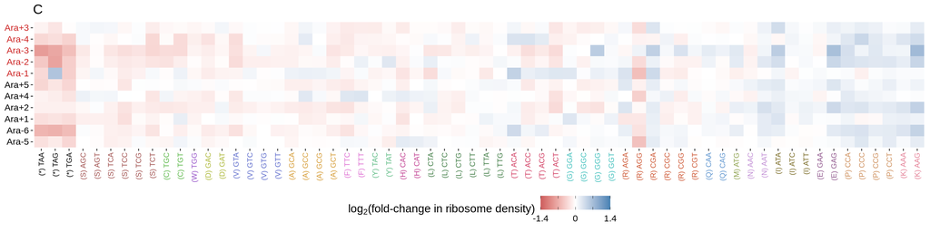

```r
pc <- rdf %>%
  ggplot(., aes(newlab, line, fill = log2(ratio)))+
  geom_raster()+
  scale_fill_gradient2(midpoint = 0,
                       breaks = c(-1.4, -.7, 0, .7, 1.4),
                       labels = c(-1.4, "", 0, "", 1.4),
                       name = expression(paste(log[2], "(fold-change in ribosome density)", sep = "")),
                       high = "steelblue", low = "indianred",
                       limits = c(-1.4, 1.4),
                       guide = guide_colorbar(ticks.colour = "black"))+
  theme(axis.text.x = element_text(angle = 90, color = all.my.colors, hjust = 1, vjust = .5, size = 9),
        text = element_text(size = 14),
        axis.text.y = element_text(color = mut.colors),
        panel.background = element_blank(),
        legend.position = "bottom")+
  labs(x = NULL, y = NULL, title = "C")

pc
```

### Panel D

Termination factor mutations and fold changes. This heatmap will have color as fold changes and some symbols to denote significance and presence/absence of a mutation. Mark genes with mutations.

```r
# these are termination factors
prots <- c("ECB_01186", "ECB_04250", "ECB_00170", "ECB_02723", "ECB_03191", "ECB_01187", "ECB_00231", "ECB_00230", "ECB_04017")

term.names <- all.data %>%
  filter(target_id %in% prots) %>%
  pull(rel_name) %>%
  unique()

missing.df <- data.frame(
  population = rep(unique(all.data$line), length(term.names)),
  gene_name = rep(term.names, each = length(unique(all.data$line))),
  value2 = 0
)

muts.df <- sapply(term.names, function(x){
  my.mutations %>%
    filter(grepl(x, gene_list))
}, simplify = FALSE) %>%
  bind_rows() %>%
  select(population, gene_name) %>%
  mutate(value = 1) %>%
  full_join(missing.df) %>%
  mutate(value3 = value + value2) %>%
  replace_na(list("value3" = 0)) %>%
  rename("line" = "population",
         "rel_name" = "gene_name")
```

Then get the RNAseq fold changes

```r
term.fcs <- all.data %>%
  select(line, rel_name, ds_log2foldchange_rna, ds_padj_rna) %>%
  filter(rel_name %in% term.names)
```

Join them and make a label column that shows mutation status and significance.

```r
ddf <- left_join(term.fcs, muts.df) %>%
  mutate(stars = as.character(cut(
    ds_padj_rna,
    c(1, .05, .01, .001, .0001, -Inf),
    labels = c("****", "***", "**", "*", "")
  )),
  mut.sign = ifelse(value3 == 1, "M", ""),
  stars = ifelse(is.na(stars), "", stars),
  label = paste(stars, mut.sign),
  line = factor(line, levels = mut.levels)) %>%
  select(line, rel_name, ds_log2foldchange_rna, label)

head(ddf)
```

| line | rel_name | ds_log2foldchange_rna | label |
| --- | --- | --- | --- |
| Ara-1 | frr | 0.16114061 |  |
| Ara-1 | ykfJ | -0.33886391 |  |
| Ara-1 | prfH | -0.26410896 |  |
| Ara-1 | prfA | 0.03596189 |  |
| Ara-1 | prmC | 0.20751303 |  |
| Ara-1 | prfB | 0.52141969 | M |

Plot it

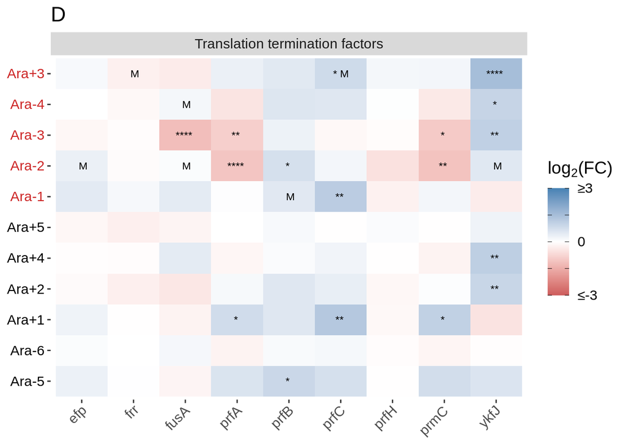

```r
scale.labels <- c(paste("\u2264", paste0("-", 3), sep = ""),
                  "",
                  0,
                  "",
                  paste("\u2265", 3, sep = ""))

pd <- ddf %>%
  mutate(newfc = ifelse(ds_log2foldchange_rna < -3, -3,
                        ifelse(ds_log2foldchange_rna > 3, 3, ds_log2foldchange_rna)),
         facet = "Translation termination factors") %>%
  ggplot(., aes(rel_name, line, fill = newfc, label = label))+
  geom_raster()+
  geom_text(size = 3)+
  scale_fill_gradientn(colors = c("indianred", "white", "steelblue"),
                       name = expression(paste(log[2], "(FC)")), limits = c(-3, 3),
                       labels = scale.labels,
                       breaks = c(-3, -1.5, 0, 1.5, 3),
                       guide = guide_colorbar(ticks.colour = "black"))+
  theme(panel.background = element_blank(),
        panel.grid = element_blank(),
        text = element_text(size = 14),
        axis.text.y = element_text(color = mut.colors),
        axis.text.x = element_text(angle = 45, vjust = 1.1, hjust = 1.1))+
  labs(x = NULL,
       y = NULL,
       title= "D")+
  facet_wrap(~facet)

pd
```

### Final figure

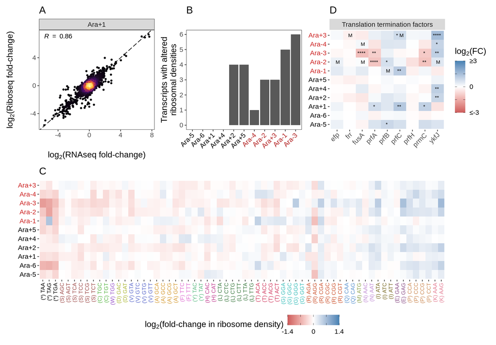

```r
top <- pa | pb | pd

ff <- top / pc

ff
```

Save it in various formats

```r
ggsave(ff, filename = "../../figures/fig_3.png", width = 11.5, height = 8)

ggsave(ff, filename = "../../figures/fig_3.pdf", device = cairo_pdf, width = 11.5, height = 8)

write_rds(ff, "../../figures/fig_3.rds")
```

### Modeling

This has a figure but only makes it into the paper as textual description

We use a linear mixed model to look for differences between stop codons and the rest of the amino acids while accounting for the individual line differences. The following is modified code from Alex Cope.

```r
model.input <- rdf %>%
  select(line, codon, amino_acid, ratio) %>%
  mutate(class = ifelse(amino_acid == "*", "stop", "aa"),
         ratio = log2(ratio))
```

Fit a null model

```r
model.0 <- lm(ratio~class,data=model.input)
```

Try various models

```r
## Random intercept, same slope
model.1 <- lme(fixed=ratio~class, random=~1|line,data = model.input,method = "ML",control=list(opt="optim",niterEM=100,maxIter=500,msMaxIter=500))


## Following example here https://rpsychologist.com/r-guide-longitudinal-lme-lmer for uncorrelated random intercept and random slope
model.2 <- lme(fixed=ratio~class, random=list(line = pdDiag(~class)),data = model.input,method = "ML",control=list(opt="optim",niterEM=100,maxIter=500,msMaxIter=500))


## Random slope, same intercept
model.3 <- lme(fixed=ratio~class, random=~0+class|line,data = model.input,method = "ML",control=list(opt="optim",niterEM=100,maxIter=500,msMaxIter=500))


## Random slope of x within group with correlated intercept (i.e. slope and intercept covary)
model.4 <- lme(fixed=ratio~class, random=~class|line,data = model.input,method = "ML",control=list(opt="optim",niterEM=100,maxIter=500,msMaxIter=500))
```

Compare the model fits

```r
(model.table <- anova(model.4,model.3,model.2,model.1,model.0))
```

|  | call | Model | df | AIC | BIC | logLik | Test | L.Ratio | p-value |
| --- | --- | --- | --- | --- | --- | --- | --- | --- | --- |
| model.4 | lme.formula(fixed = ratio ~ class, data = model.input, random = ~class \| line, method = "ML", control = list(opt = "optim", niterEM = 100, maxIter = 500, msMaxIter = 500)) | 1 | 6 | -583.3127 | -555.9721 | 297.6564 |  | NA | NA |
| model.3 | lme.formula(fixed = ratio ~ class, data = model.input, random = ~0 + class \| line, method = "ML", control = list(opt = "optim", niterEM = 100, maxIter = 500, msMaxIter = 500)) | 2 | 6 | -583.3139 | -555.9732 | 297.6569 |  | NA | NA |
| model.2 | lme.formula(fixed = ratio ~ class, data = model.input, random = list(line = pdDiag(~class)), method = "ML", control = list(opt = "optim", niterEM = 100, maxIter = 500, msMaxIter = 500)) | 3 | 5 | -585.2347 | -562.4508 | 297.6173 | 2 vs 3 | 0.079222365 | 7.783540e-01 |
| model.1 | lme.formula(fixed = ratio ~ class, data = model.input, random = ~1 \| line, method = "ML", control = list(opt = "optim", niterEM = 100, maxIter = 500, msMaxIter = 500)) | 4 | 4 | -556.4731 | -538.2460 | 282.2366 | 3 vs 4 | 30.761566076 | 2.917596e-08 |
| model.0 | lm(formula = ratio ~ class, data = model.input) | 5 | 3 | -558.4769 | -544.8066 | 282.2384 | 4 vs 5 | 0.003792158 | 9.508969e-01 |

Pick the simplest one

```r
model.list <- list(model.4,model.3,model.2,model.1,model.0)
best.model <- model.list[[which.min(model.table$AIC)]]
```

QC plots don't look too great

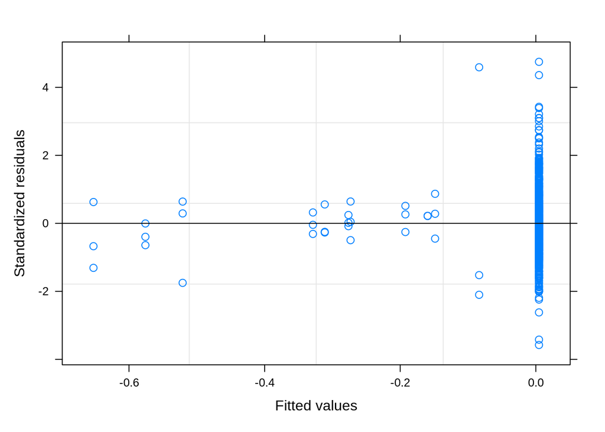

```r
plot(best.model)
```

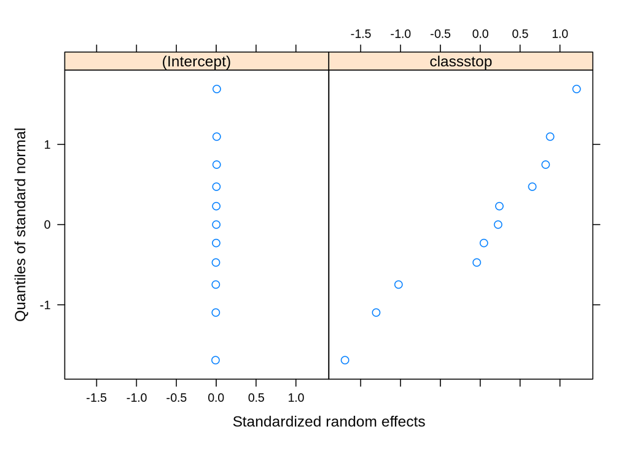

```r
qqnorm(best.model, ~ranef(.,standard=T))
```

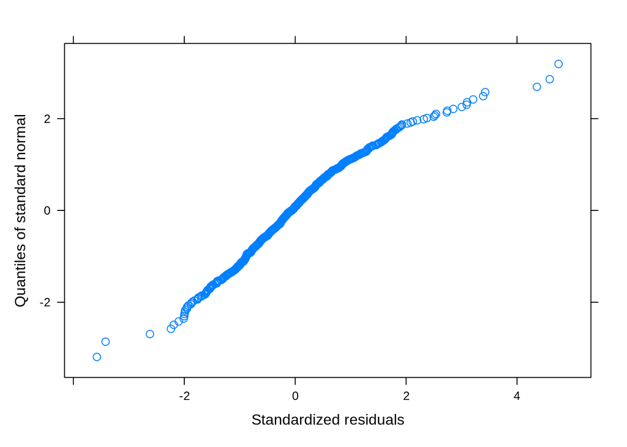

```r
qqnorm(best.model,~resid(.,type="p"))
```

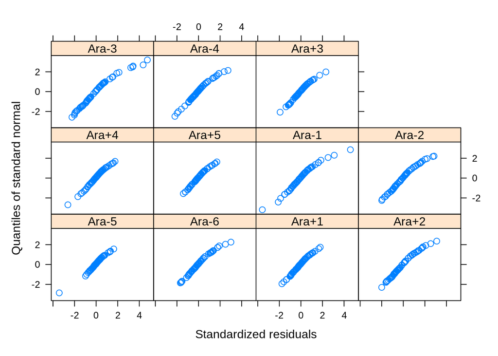

```r
qqnorm(best.model,~resid(.,type="p") | line )
```

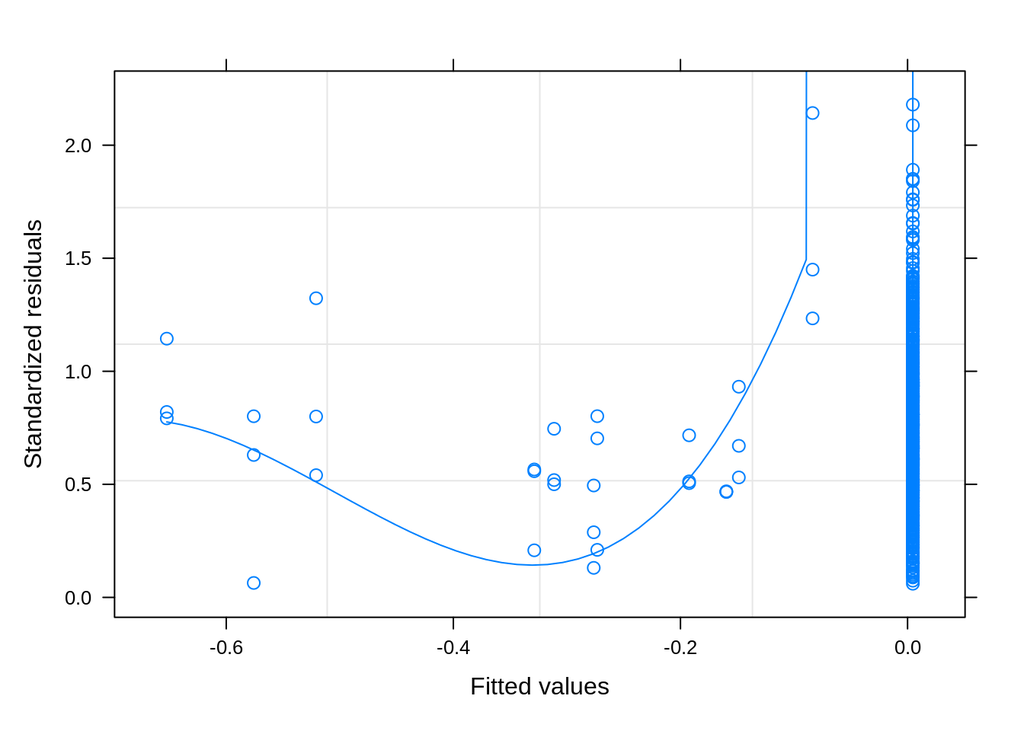

```r
plot(best.model,sqrt(abs(resid(., type = "p"))) ~ fitted(.), type = c("p", "smooth"))
```

A plot showing the effects

```r
random.ef.df <- random.effects(best.model) %>%
  as_tibble(rownames = "line")

coef.df <- coef(best.model) %>%
  as_tibble(rownames = "line")

plot.df <- bind_rows("Random effect estimates" = random.ef.df, "Slope estimates" = coef.df, .id = "type") %>%
  mutate(line = factor(line, levels = mut.levels))
```

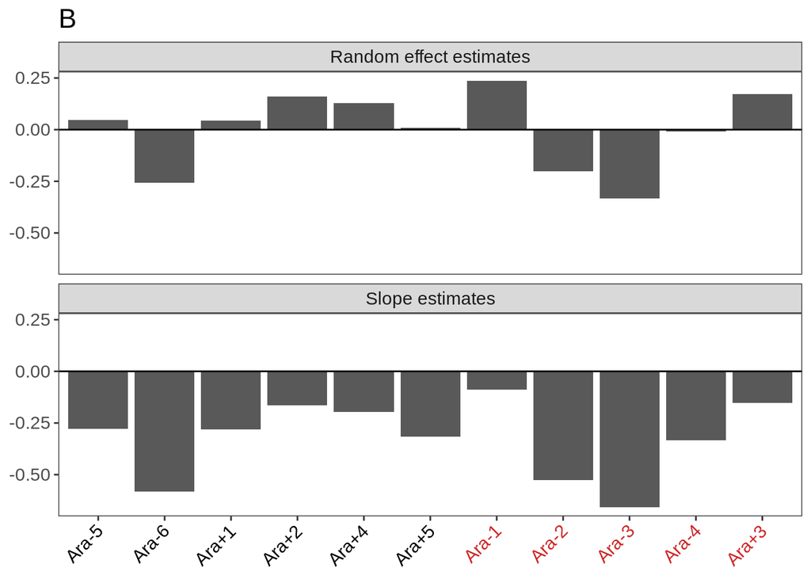

```r
plot.df %>%
  ggplot(., aes(line, classstop))+
  geom_col()+
  geom_hline(aes(yintercept = 0))+
  facet_wrap(~type, ncol = 1)+
  theme_bw()+
  theme(text = element_text(size = 14),
        panel.grid = element_blank(),
        axis.text.x = element_text(angle = 45, vjust = 1.1, hjust = 1.1, color = mut.colors))+
  labs(x = NULL,
       y = NULL,
       title = "B")
```

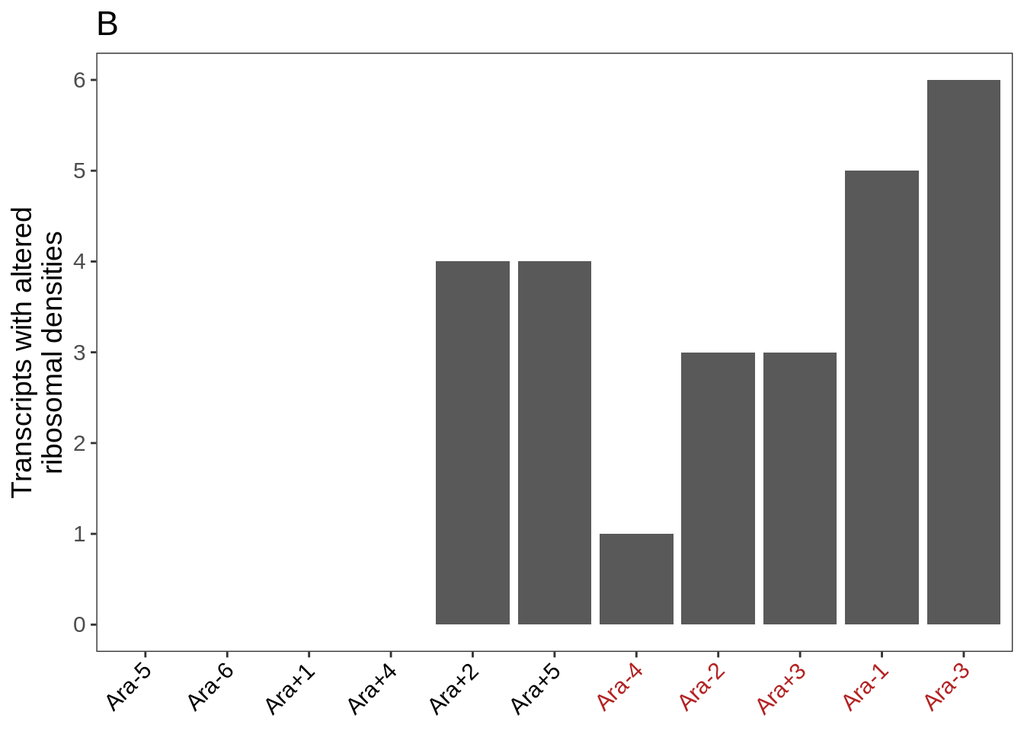

```r
pb
```